# Fraud

Christine Iyer

October 2, 2017

We are delighted to have you continue on in our interview process! Please complete the scenario below. The set of data needed to review is attached separately as an excel document. Feel free to manipulate the document. You will be presenting your solution and findings during your onsite interview with the management team.

Operational Scenario: *See Excel Document Attached

We have 3 locations staffed with manual fraud reviewers: Atlantic City, Montreal, and Ibiza. Fraud reviewers in this position will evaluate orders for fraudulent activity and decide to cancel or pass the order. We have 13 total reviewers that we can allocate to any location. Each reviewer can look at 100 orders per hour and work 8 hours total per day.

* Ibiza is staffed from 2a-10a EST (6 hours ahead)

Using the data in the attached spreadsheet please analyze and recommend your staffing recommendations for all 3 locations assuming that this data will remain constant year round. The spreadsheet contains one month of order data with order times and dates. In addition to a staffing recommendation please highlight any other trends that you see in our fraud data. Would you have any further questions on the ask? What would your next steps be? Please be ready to make your recommendation and highlight any trends that you find in a short 5- minute presentation using your preferred method to present (Power Point, Excel, etc…).

```r
library(knitr)
library(dplyr)
```

```r
library(ggplot2)
```

```r
fraud <- read.csv("test_frauddata.csv", header = T, stringsAsFactors = F)
fraud$OrderDate <- as.Date(fraud$OrderDate, format = "%m/%d/%Y")
fraud <- fraud %>% rename(Fraudulent = OrderIsFraudulent..1.yes..0.No., Revenue = OrderRevenue,State = OrderState ) %>% arrange(OrderDate)
kable(head(fraud))
```

| OrderNumber | OrderDate | OrderDayWeek | OrderHour | Fraudulent | Revenue | State | Country | Website |
| --- | --- | --- | --- | --- | --- | --- | --- | --- |
| 9.12141e+15 | 2016-08-01 | Monday | 21 | 0 | 4367.56 | Saskatchewan | Canada | Wayfair.ca |
| 9.12142e+15 | 2016-08-01 | Monday | 20 | 0 | 46.35 | Florida | USA | Wayfair |
| 9.12145e+15 | 2016-08-01 | Monday | 19 | 0 | 435.98 | Oregon | USA | AllModern |
| 9.12146e+15 | 2016-08-01 | Monday | 11 | 1 | 1349.99 | Québec | Canada | Wayfair.ca |
| 9.12154e+15 | 2016-08-01 | Monday | 8 | 0 | 3959.99 | Nova Scotia | Canada | Wayfair.ca |
| 9.12156e+15 | 2016-08-01 | Monday | 7 | 0 | 1049.99 | Florida | USA | Wayfair |

```r
kable(tail(fraud))
```

|  | OrderNumber | OrderDate | OrderDayWeek | OrderHour | Fraudulent | Revenue | State | Country | Website |
| --- | --- | --- | --- | --- | --- | --- | --- | --- | --- |
| 81238 | 9.12229e+15 | 2016-08-30 | Tuesday | 23 | 0 | 2268.74 | Florida | USA | Wayfair |
| 81239 | 9.12229e+15 | 2016-08-30 | Tuesday | 23 | 0 | 572.95 | Florida | USA | Wayfair |
| 81240 | 9.12229e+15 | 2016-08-30 | Tuesday | 23 | 0 | 629.98 | Saskatchewan | Canada | Wayfair.ca |
| 81241 | 9.12229e+15 | 2016-08-30 | Tuesday | 23 | 0 | 690.00 | Texas | USA | AllModern |
| 81242 | 9.12229e+15 | 2016-08-30 | Tuesday | 23 | 0 | 273.99 | California | USA | Wayfair |
| 81243 | 9.12229e+15 | 2016-08-30 | Tuesday | 23 | 0 | 1401.29 | Ohio | USA | Wayfair |

Time Zones

This calculates the time differences to correct for Eastern Times

```r
USCanadaZones <- read.csv("USCAZones.csv", header = T, stringsAsFactors = F)
fraud11 <- inner_join(fraud, USCanadaZones)
fraud11 <- fraud11 %>% mutate(orderEasternTime = OrderHour + differenceZone)
#kable(tail(fraud11, 100))
#range(fraud11$orderEasternTime)
#dim(fraud11)
fraud111 <- fraud11 %>% mutate(correctedTime = ifelse(orderEasternTime>23, orderEasternTime - 24, ""))
#kable(tail(fraud111, 100))
#fraud11 %>% filter(orderEasternTime < 0 | orderEasternTime>23) %>% group_by(State) %>% summarise(n = n())
```

# Corrected Zones

```r
fraud111 <- fraud11 %>% mutate(orderEasternTime = ifelse(orderEasternTime>23, orderEasternTime - 24, ifelse(orderEasternTime<0, orderEasternTime +24, orderEasternTime)))
#fraud111 <- fraud111 %>% mutate(correctedTime = ifelse(orderEasternTime<0, orderEasternTime + 24, orderEasternTime))
kable(tail(fraud111, 100))
```

[output not shown]

[output cut: 70 more lines]

Below is how many orders there were each day of the month.

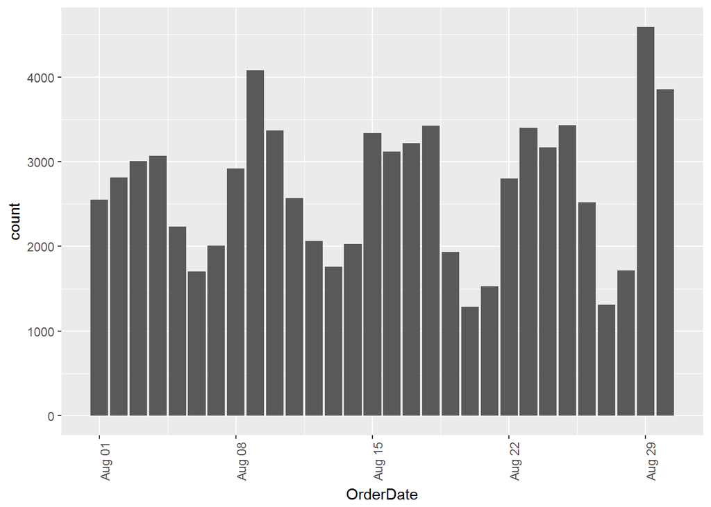

```r
ggplot(fraud111, aes(x = OrderDate))+ geom_bar() + theme(axis.text.x = element_text(angle = 90, hjust = 1))
```

Below is the same data grouped by day of the week.

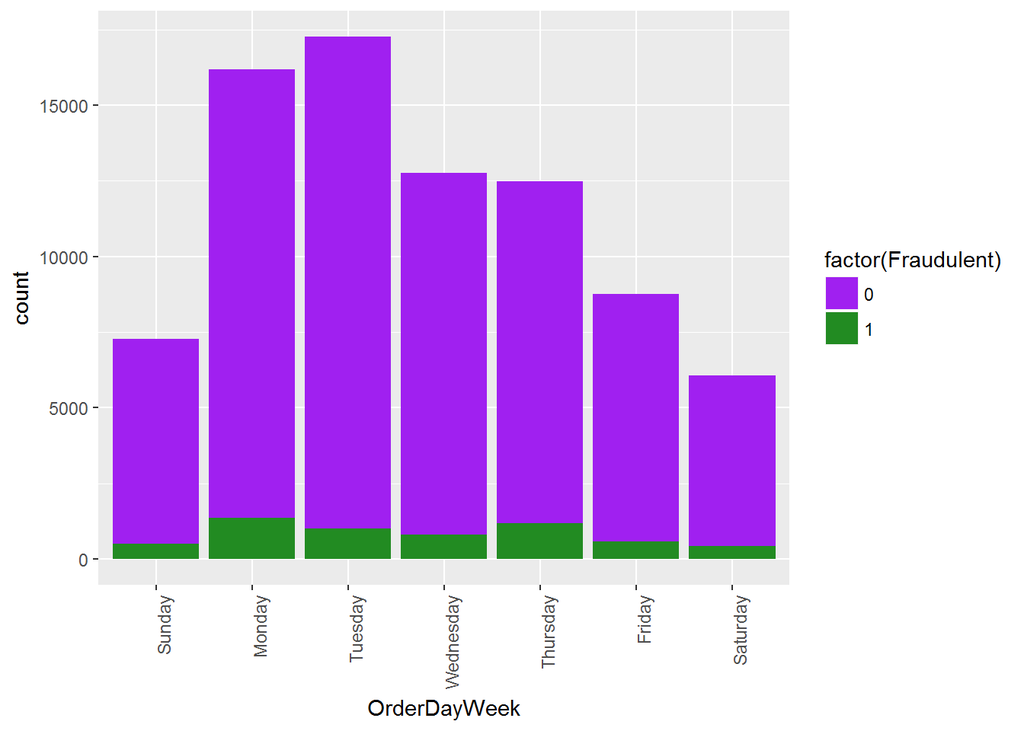

```r
fraud111$OrderDayWeek <- factor(fraud111$OrderDayWeek, levels= c("Sunday", "Monday",
    "Tuesday", "Wednesday", "Thursday", "Friday", "Saturday"))
ggplot(fraud111, aes(x = OrderDayWeek, fill = factor(Fraudulent), group = (Fraudulent) )) + geom_bar() + theme(axis.text.x = element_text(angle = 90, hjust = 1)) +
  scale_fill_manual(values=c('purple',
'forestgreen'))
```

```r
fraudulentDays <- fraud111 %>% group_by(OrderDayWeek, Fraudulent) %>% summarise(count = n()) %>% mutate(perc= round(count/sum(count)*100, digits = 2))

fraudulentDays
```

```
## # A tibble: 14 x 4
## # Groups:   OrderDayWeek [7]
##    OrderDayWeek Fraudulent count  perc
##          <fctr>      <int> <int> <dbl>
##  1       Sunday          0  6771 92.97
##  2       Sunday          1   512  7.03
##  3       Monday          0 14836 91.59
##  4       Monday          1  1363  8.41
##  5      Tuesday          0 16259 94.20
##  6      Tuesday          1  1001  5.80
##  7    Wednesday          0 11961 93.75
##  8    Wednesday          1   797  6.25
##  9     Thursday          0 11326 90.64
## 10     Thursday          1  1170  9.36
## 11       Friday          0  8184 93.50
## 12       Friday          1   569  6.50
## 13     Saturday          0  5639 93.04
## 14     Saturday          1   422  6.96
```

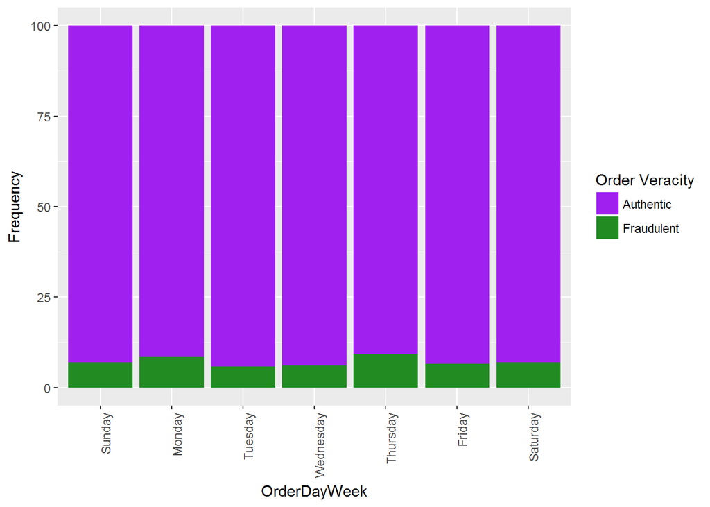

```r
ggplot(fraudulentDays, aes(x = OrderDayWeek, y = perc, fill = factor(Fraudulent), group = (Fraudulent))) + geom_bar(stat="identity") + theme(axis.text.x = element_text(angle = 90, hjust = 1))  +
  scale_fill_manual(values=c('purple','forestgreen'), name="Order Veracity",labels=c("Authentic", "Fraudulent")) +  ylab("Frequency")
```

```r
fraudulentTimes <- fraud111 %>% group_by(orderEasternTime, Fraudulent) %>% summarise(count = n()) %>% mutate(perc= round(count/sum(count), digits = 3))
fraudulentTimes
```

```
## # A tibble: 48 x 4
## # Groups:   orderEasternTime [24]
##    orderEasternTime Fraudulent count  perc
##               <dbl>      <int> <int> <dbl>
##  1                0          0  1620 0.882
##  2                0          1   217 0.118
##  3                1          0   877 0.836
##  4                1          1   172 0.164
##  5                2          0   561 0.798
##  6                2          1   142 0.202
##  7                3          0   302 0.701
##  8                3          1   129 0.299
##  9                4          0   297 0.752
## 10                4          1    98 0.248
## # ... with 38 more rows
```

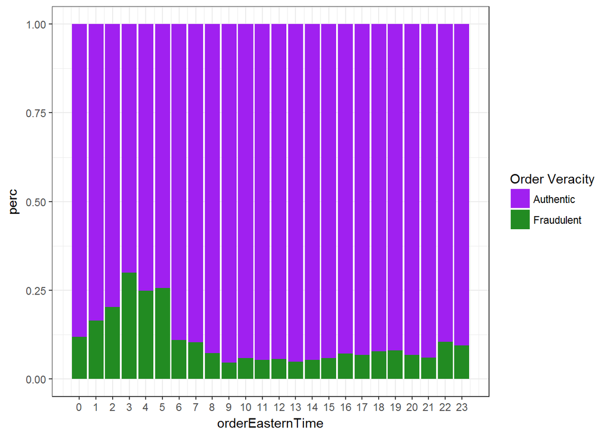

```r
ggplot(fraudulentTimes, aes(x = orderEasternTime, y = perc , fill = factor(Fraudulent), group = factor(Fraudulent))) + geom_bar(stat="identity") + theme(axis.text.x = element_text(angle = 90, hjust = 1))  +
  scale_fill_manual(values=c('purple',
'forestgreen'), name="Order Veracity",labels=c("Authentic", "Fraudulent")) + scale_x_continuous(breaks = 0:23) + theme_bw()
```

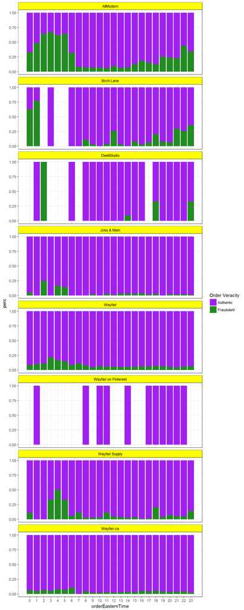

```r
fraudulentTimesSites <- fraud111 %>% group_by(orderEasternTime, Website, Fraudulent) %>% summarise(count = n()) %>% mutate(perc= round(count/sum(count), digits = 3))
ggplot(fraudulentTimesSites, aes(x = orderEasternTime, y = perc , fill = factor(Fraudulent), group = factor(Fraudulent))) + geom_bar(stat="identity") + theme(axis.text.x = element_text(angle = 90, hjust = 1))  +
  scale_fill_manual(values=c('purple',
'forestgreen'), name="Order Veracity",labels=c("Authentic", "Fraudulent")) + scale_x_continuous(breaks = 0:23)+ facet_wrap(~Website, ncol = 1) + theme_bw() +
  theme(strip.background =element_rect(fill="yellow"))+
  theme(strip.text = element_text(colour = 'black'))
```

```r
#range(fraudulentTimes$perc)
#+ geom_text(aes(label=perc, size=3),
```

```r
A <- fraud %>% filter(State == "Queensland")
B <- fraud %>% filter(State == "New South Wales")
C <- fraud %>% filter(State == "South Australia")
D <- fraud %>% filter(State == "Victoria")
UnknownCountry <- rbind.data.frame(A,B,C,D)
UnknownCountry
```

```
##    OrderNumber  OrderDate OrderDayWeek OrderHour Fraudulent Revenue
## 1  9.12224e+15 2016-08-03    Wednesday         4          0  233.50
## 2  9.12224e+15 2016-08-07       Sunday        21          0  425.94
## 3  9.12227e+15 2016-08-24    Wednesday         1          0  157.47
## 4  9.12229e+15 2016-08-25     Thursday        13          0  166.04
## 5  9.12226e+15 2016-08-01       Monday        18          1  156.99
## 6  9.12217e+15 2016-08-03    Wednesday        23          0  109.99
## 7  9.12222e+15 2016-08-05       Friday        23          0 1218.44
## 8  9.12224e+15 2016-08-08       Monday        10          0 1148.45
## 9  9.12227e+15 2016-08-10    Wednesday        16          0  123.99
## 10 9.12228e+15 2016-08-10    Wednesday        20          0   86.99
## 11 9.12228e+15 2016-08-11     Thursday        18          1  145.16
## 12 9.12228e+15 2016-08-13     Saturday        19          0  200.98
## 13 9.12224e+15 2016-08-15       Monday        15          0  149.99
## 14 9.12226e+15 2016-08-15       Monday        21          0  717.27
```

[output cut: 43 more lines]

```r
E <- fraud %>% group_by(State, Country) %>% summarise(TotalOrders = n(), TotalRev = sum(Revenue))
FF <- fraud %>% group_by(State, Country) %>% summarise(FraudulentOrders = sum(Fraudulent))
G <- fraud %>% filter(Fraudulent == 1) %>%  group_by(State) %>% summarise(TotalFraudulentRevenue = sum(Revenue))

H <- inner_join(FF, E)
I <- left_join(H, G)
PercentFraud <- I %>% mutate(pctFrOrders = round(FraudulentOrders/TotalOrders, digits = 2), pctRevLost = round(TotalFraudulentRevenue/TotalRev, digits = 2), AvAmtFraudOrder = round(TotalFraudulentRevenue/FraudulentOrders, digits = 2)) %>% arrange(desc(TotalFraudulentRevenue))
PercentFraud
```

```
## # A tibble: 72 x 9
## # Groups:   State [72]
##               State Country FraudulentOrders TotalOrders TotalRev
##               <chr>   <chr>            <int>       <int>    <dbl>
##  1       California     USA              634       10311  9375775
##  2          Florida     USA              386        6719  6274549
##  3         New York     USA             1411        8408  6384112
##  4            Texas     USA              262        5308  5128901
##  5          Ontario  Canada              120        4151  4267023
##  6         Illinois     USA              133        2671  2357301
##  7 British Columbia  Canada               76        1649  1885269
##  8     Pennsylvania     USA              121        2360  2245419
##  9          Georgia     USA              109        2261  2006822
## 10          Alberta  Canada               48        1411  1565668
## # ... with 62 more rows, and 4 more variables:
## #   TotalFraudulentRevenue <dbl>, pctFrOrders <dbl>, pctRevLost <dbl>,
## #   AvAmtFraudOrder <dbl>
```

```r
#write.csv(PercentFraud, "PctFraud.csv", row.names = F)
PercentFraud %>% group_by(Country) %>% summarise(NumberFraudOrders = sum(FraudulentOrders), TotalOrders = sum(TotalOrders), TotalFraudAmount = sum(TotalFraudulentRevenue), sumTotalRev = sum(TotalRev)) %>% mutate(PercentFraudOrders = round(NumberFraudOrders/TotalOrders, digits = 3))
```

```
## # A tibble: 3 x 6
##   Country NumberFraudOrders TotalOrders TotalFraudAmount sumTotalRev
##     <chr>             <int>       <int>            <dbl>       <dbl>
## 1                         3          28               NA    12482.97
## 2  Canada               342        9197               NA  9621946.88
## 3     USA              5502       72018               NA 64493649.97
## # ... with 1 more variables: PercentFraudOrders <dbl>
```

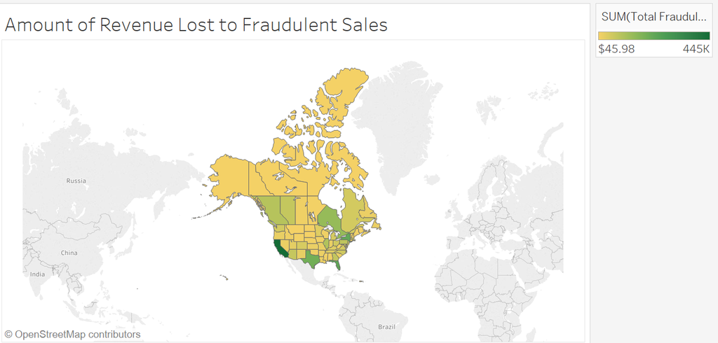

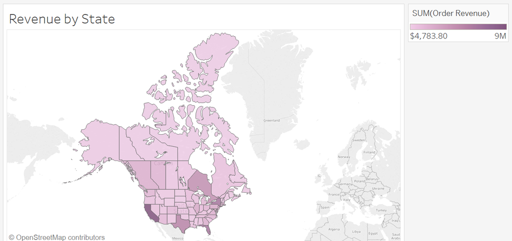